# Final Project

```r
# select the best
show_best(boostedtree_tune_res, metric = "roc_auc") %>%
  select(-.estimator, .config) %>%
  slice(1)
```

```
## # A tibble: 1 × 6
##   trees .metric  mean     n std_err .config
##   <int> <chr>   <dbl> <int>   <dbl> <chr>
## 1    10 roc_auc 0.967     5 0.00491 Preprocessor1_Model01
```

```r
# fit model to testing data
grades_predict <- predict(xgb_final_fit1,
                          new_data = grades_test_fctr,
                          type = "class")

# adding the actual values side by side to our predicted values
grades_predict_with_actual <- grades_predict %>%
  bind_cols(grades_test_fctr %>% select(g3))
grades_predict_with_actual
```

```
## # A tibble: 314 × 2
##    .pred_class g3
##    <fct>       <fct>
##  1 Fail        Fail
##  2 Pass        Pass
##  3 Pass        Pass
##  4 Pass        Pass
##  5 Fail        Fail
##  6 Pass        Pass
##  7 Fail        Fail
##  8 Pass        Pass
##  9 Pass        Pass
## 10 Fail        Pass
## # … with 304 more rows
```

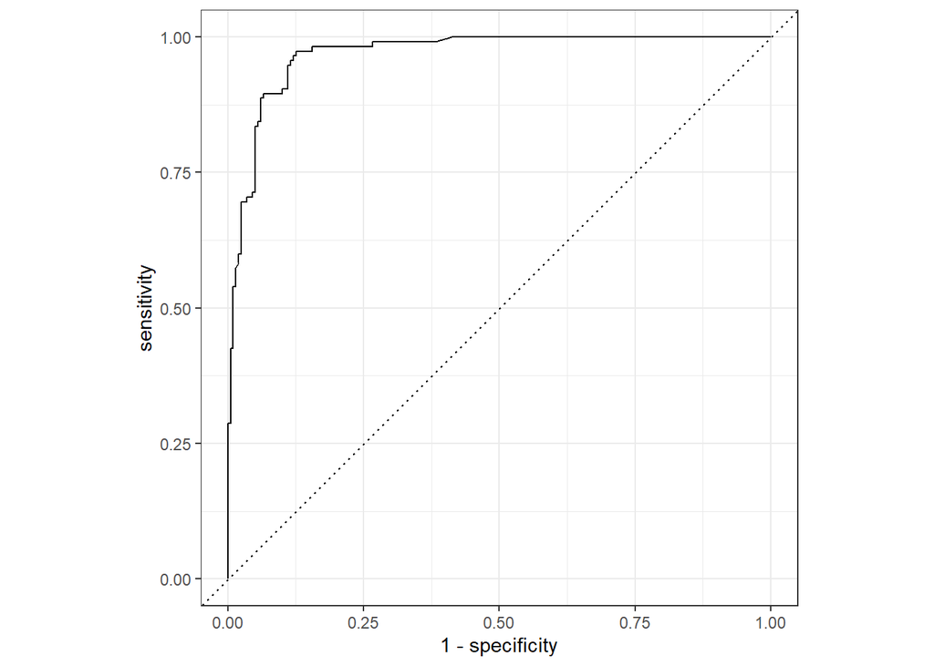

```r
# computing the ROC curve for this model
grades_roc_curve <- augment(xgb_final_fit1, new_data = grades_test_fctr) %>%
  roc_curve(truth = g3, estimate = .pred_Fail)
autoplot(grades_roc_curve)
```

```r
# computing the AUC for the ROC curve
finalgrades_acc <- augment(xgb_final_fit1, new_data = grades_test_fctr) %>%
  accuracy(truth = g3, estimate = .pred_class) %>%
  select(.estimate)
finalgrades_acc
```

```
## # A tibble: 1 × 1
##   .estimate
##       <dbl>
## 1     0.904
```

```r
finalgrades_roc_auc <- augment(xgb_final_fit1, new_data = grades_test_fctr) %>%
  roc_auc(truth = g3, estimate = .pred_Fail) %>%
  select(.estimate)
finalgrades_roc_auc
```

```
## # A tibble: 1 × 1
##   .estimate
##       <dbl>
## 1     0.968
```

The boosted tree model using Method 1, merged dataset, gave us a 0.9044586 accuracy and 0.968298 roc_auc on the testing data.

- If we wanted to take our analysis further, I might try fitting a random forest model and/or k nearest neighbors. The boosted tree did the best, better than the individual decision tree model, which may be a result of collecting knowledge from fitting several trees instead of just one. (In which case a random forest would also give great results) I would also explore why the accuracy and roc_auc values decreased after conducting k-fold cross validation on the logistic regression model.
- While there was initially concern of how our outcome variable (G3) would perform with a regression versus classification model due to uneven proportions of grade categories, this was remedied by instead splitting G3 grades into “Fail” and “Pass” labels. We chose classification because this new labeling system worked so well, giving us accuracies and roc_auc values of mostly 0.9 or upwards.
- To answer our experiment of choosing Method 1 or 2, most models performed better when using Method 1. Perhaps this is telling us that there is still detectable difference between the Maths and Portuguese datasets, such that when a model is only trained on one of the datasets, it still has some difficulty predicting on the testing data.
- The variables that most heavily influence a student’s G3 grades are their G1, G2 grades, past failures, and alcohol consumption (moreso weekend alcohol consumption). Mother’s education and Father’s education are correlated among themselves, but their relationships with G3 grades can be further investigated.

This was a great project to work on, I thoroughly enjoyed it because of my love for exploring the intersection between statistics, data, education, and the ways each field can enhance one another. Working with grades data and observing which factors heavily impact performance is a great first step in targeting the needs and kinds of resources needed to support students. My goal in the future is to use data analysis methods to better understand the needs, goals, and backgrounds of students, which will hopefully help me find ways to motivate and help them excel in their careers.

[figure not shown]